# ISLR-R: 6. Association Analysis

2023-05-17

## Association Analysis using the Apriori algorithm

> need the `arules` package.

We can then read in the .csv file, converting it to a list of transactions:

```r
data <- arules::read.transactions(
  file = "../data/Basket1.txt",
  format = "basket", sep = ","
)
arules::inspect(data)
```

```
##     items
## [1] {Bread, Milk}
## [2] {Beer, Bread, Diapers, Eggs}
## [3] {Beer, Cola, Diapers, Milk}
## [4] {Beer, Bread, Diapers, Milk}
## [5] {Bread, Cola, Diapers, Milk}
```

### Frequent Item Sets

We can mine the frequent itemsets, view all the frequent itemsets, and view the five most frequent itemsets with the greatest support using the following code:

```r
items <- arules::apriori(data,
  parameter = list(
    support = 0.4,
    confidence = 0.8, target = "frequent itemsets"
  )
)
```

```
## Apriori
##
## Parameter specification:
##  confidence minval smax arem  aval originalSupport maxtime support minlen
##          NA    0.1    1 none FALSE            TRUE       5     0.4      1
##  maxlen            target  ext
##      10 frequent itemsets TRUE
##
## Algorithmic control:
##  filter tree heap memopt load sort verbose
##     0.1 TRUE TRUE  FALSE TRUE    2    TRUE
##
## Absolute minimum support count: 2
##
## set item appearances ...[0 item(s)] done [0.00s].
## set transactions ...[6 item(s), 5 transaction(s)] done [0.00s].
## sorting and recoding items ... [5 item(s)] done [0.00s].
## creating transaction tree ... done [0.00s].
## checking subsets of size 1 2 3 done [0.00s].
## sorting transactions ... done [0.00s].
## writing ... [17 set(s)] done [0.00s].
## creating S4 object  ... done [0.00s].
```

```r
arules::inspect(items)
```

```
##      items                  support count
## [1]  {Cola}                 0.4     2
## [2]  {Beer}                 0.6     3
## [3]  {Milk}                 0.8     4
## [4]  {Bread}                0.8     4
## [5]  {Diapers}              0.8     4
## [6]  {Cola, Milk}           0.4     2
## [7]  {Cola, Diapers}        0.4     2
## [8]  {Beer, Milk}           0.4     2
## [9]  {Beer, Bread}          0.4     2
## [10] {Beer, Diapers}        0.6     3
## [11] {Bread, Milk}          0.6     3
## [12] {Diapers, Milk}        0.6     3
## [13] {Bread, Diapers}       0.6     3
## [14] {Cola, Diapers, Milk}  0.4     2
## [15] {Beer, Diapers, Milk}  0.4     2
## [16] {Beer, Bread, Diapers} 0.4     2
## [17] {Bread, Diapers, Milk} 0.4     2
```

```r
arules::inspect(arules::sort(items, by = "support")[1:5])
```

```
##     items           support count
## [1] {Milk}          0.8     4
## [2] {Bread}         0.8     4
## [3] {Diapers}       0.8     4
## [4] {Beer}          0.6     3
## [5] {Beer, Diapers} 0.6     3
```

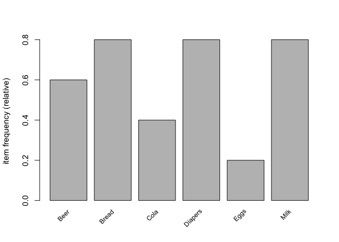

```r
# cex.names adjusts the size of the labels on the bars
arules::itemFrequencyPlot(data, support = 0.1, cex.names = 0.8)
```

### Maximal Frequent Item Sets

We can mine the maximal frequent itemsets, and view all the maximal frequent itemsets using this code:

```r
MaxFreqItemsets <- arules::apriori(data,
  parameter = list(
    support = 0.3,
    target = "maximally frequent itemsets"
  )
)
```

```
## Apriori
##
## Parameter specification:
##  confidence minval smax arem  aval originalSupport maxtime support minlen
##          NA    0.1    1 none FALSE            TRUE       5     0.3      1
##  maxlen                      target  ext
##      10 maximally frequent itemsets TRUE
##
## Algorithmic control:
##  filter tree heap memopt load sort verbose
##     0.1 TRUE TRUE  FALSE TRUE    2    TRUE
##
## Absolute minimum support count: 1
##
## set item appearances ...[0 item(s)] done [0.00s].
## set transactions ...[6 item(s), 5 transaction(s)] done [0.00s].
## sorting and recoding items ... [5 item(s)] done [0.00s].
## creating transaction tree ... done [0.00s].
## checking subsets of size 1 2 3 done [0.00s].
## filtering maximal item sets ... done [0.00s].
## sorting transactions ... done [0.00s].
## writing ... [4 set(s)] done [0.00s].
## creating S4 object  ... done [0.00s].
```

```r
arules::inspect(MaxFreqItemsets)
```

```
##     items                  support count
## [1] {Cola, Diapers, Milk}  0.4     2
## [2] {Beer, Diapers, Milk}  0.4     2
## [3] {Beer, Bread, Diapers} 0.4     2
## [4] {Bread, Diapers, Milk} 0.4     2
```

```r
summary(MaxFreqItemsets)
```

```
##   Length    Class     Mode
##        4 itemsets       S4
```

### Closed Frequent Item Sets

We can mine the closed frequent itemsets, and view all the closed frequent itemsets using this code:

```r
ClosedFreqItemsets <- arules::apriori(data,
  parameter = list(
    support = 0.4,
    target = "closed frequent itemsets"
  )
)
```

```
## Apriori
##
## Parameter specification:
##  confidence minval smax arem  aval originalSupport maxtime support minlen
##          NA    0.1    1 none FALSE            TRUE       5     0.4      1
##  maxlen                   target  ext
##      10 closed frequent itemsets TRUE
##
## Algorithmic control:
##  filter tree heap memopt load sort verbose
##     0.1 TRUE TRUE  FALSE TRUE    2    TRUE
##
## Absolute minimum support count: 2
##
## set item appearances ...[0 item(s)] done [0.00s].
## set transactions ...[6 item(s), 5 transaction(s)] done [0.00s].
## sorting and recoding items ... [5 item(s)] done [0.00s].
## creating transaction tree ... done [0.00s].
## checking subsets of size 1 2 3 done [0.00s].
## filtering closed item sets ... done [0.00s].
## sorting transactions ... done [0.00s].
## writing ... [11 set(s)] done [0.00s].
## creating S4 object  ... done [0.00s].
```

```r
summary(ClosedFreqItemsets)
```

```
##   Length    Class     Mode
##       11 itemsets       S4
```

```r
arules::inspect(ClosedFreqItemsets)
```

```
##      items                  support count
## [1]  {Milk}                 0.8     4
## [2]  {Bread}                0.8     4
## [3]  {Diapers}              0.8     4
## [4]  {Beer, Diapers}        0.6     3
## [5]  {Bread, Milk}          0.6     3
## [6]  {Diapers, Milk}        0.6     3
## [7]  {Bread, Diapers}       0.6     3
## [8]  {Cola, Diapers, Milk}  0.4     2
## [9]  {Beer, Diapers, Milk}  0.4     2
## [10] {Beer, Bread, Diapers} 0.4     2
## [11] {Bread, Diapers, Milk} 0.4     2
```

### Rules

We can mine the association rules, view all the rules, and view the five rules which have the highest confidence as follows:

```r
rules <- arules::apriori(data,
  parameter = list(
    minlen = 2, support = 0.4,
    confidence = 0.8, target = "rules"
  )
)
```

```
## Apriori
##
## Parameter specification:
##  confidence minval smax arem  aval originalSupport maxtime support minlen
##         0.8    0.1    1 none FALSE            TRUE       5     0.4      2
##  maxlen target  ext
##      10  rules TRUE
##
## Algorithmic control:
##  filter tree heap memopt load sort verbose
##     0.1 TRUE TRUE  FALSE TRUE    2    TRUE
##
## Absolute minimum support count: 2
##
## set item appearances ...[0 item(s)] done [0.00s].
## set transactions ...[6 item(s), 5 transaction(s)] done [0.00s].
## sorting and recoding items ... [5 item(s)] done [0.00s].
## creating transaction tree ... done [0.00s].
## checking subsets of size 1 2 3 done [0.00s].
## writing ... [7 rule(s)] done [0.00s].
## creating S4 object  ... done [0.00s].
```

```r
arules::inspect(rules)
```

```
##     lhs                rhs       support confidence coverage lift count
## [1] {Cola}          => {Milk}    0.4     1          0.4      1.25 2
## [2] {Cola}          => {Diapers} 0.4     1          0.4      1.25 2
## [3] {Beer}          => {Diapers} 0.6     1          0.6      1.25 3
## [4] {Cola, Milk}    => {Diapers} 0.4     1          0.4      1.25 2
## [5] {Cola, Diapers} => {Milk}    0.4     1          0.4      1.25 2
## [6] {Beer, Milk}    => {Diapers} 0.4     1          0.4      1.25 2
## [7] {Beer, Bread}   => {Diapers} 0.4     1          0.4      1.25 2
```

```r
summary(rules)
```

```
## Length  Class   Mode
##      7  rules     S4
```

```r
arules::inspect(arules::sort(rules, by = "confidence")[1:5])
```

```
##     lhs                rhs       support confidence coverage lift count
## [1] {Cola}          => {Milk}    0.4     1          0.4      1.25 2
## [2] {Cola}          => {Diapers} 0.4     1          0.4      1.25 2
## [3] {Beer}          => {Diapers} 0.6     1          0.6      1.25 3
## [4] {Cola, Milk}    => {Diapers} 0.4     1          0.4      1.25 2
## [5] {Cola, Diapers} => {Milk}    0.4     1          0.4      1.25 2
```

Finally, we can find particular rules using this code:

```r
rules <- arules::apriori(data,
  parameter = list(
    minlen = 2, support = 0.4,
    confidence = 0.8, target = "rules"
  ),
  appearance = list(default = "lhs", rhs = "Milk")
)
```

```
## Apriori
##
## Parameter specification:
##  confidence minval smax arem  aval originalSupport maxtime support minlen
##         0.8    0.1    1 none FALSE            TRUE       5     0.4      2
##  maxlen target  ext
##      10  rules TRUE
##
## Algorithmic control:
##  filter tree heap memopt load sort verbose
##     0.1 TRUE TRUE  FALSE TRUE    2    TRUE
##
## Absolute minimum support count: 2
##
## set item appearances ...[1 item(s)] done [0.00s].
## set transactions ...[6 item(s), 5 transaction(s)] done [0.00s].
## sorting and recoding items ... [5 item(s)] done [0.00s].
## creating transaction tree ... done [0.00s].
## checking subsets of size 1 2 3 done [0.00s].
## writing ... [2 rule(s)] done [0.00s].
## creating S4 object  ... done [0.00s].
```

```r
summary(rules)
```

```
## Length  Class   Mode
##      2  rules     S4
```

```r
arules::inspect(arules::sort(rules, by = "confidence"))
```

```
##     lhs                rhs    support confidence coverage lift count
## [1] {Cola}          => {Milk} 0.4     1          0.4      1.25 2
## [2] {Cola, Diapers} => {Milk} 0.4     1          0.4      1.25 2
```

You can type `?apriori` in the console and then click on ‘APappearance’ to see how to extract more complicated rules.

### Interpretation

Parameters:

- additional rules
  - `arem`: additional rule evaluation measure
  - `minval`: its minimal value
  - `aval`: whether to compute additional evaluation measures
- `originalSupport`: indicating whether or not use the original definition of minimum support
  - If set to `TRUE` (which is the default), the support of a rule is considered as the frequency of both the LHS and RHS of the rule appearing together in the transactions.
  - If set to `FALSE`, the support of a rule is considered as the frequency of just the LHS of the rule appearing in the transactions (also known as the coverage of the rule).
- `minlen`: minimum number of items that a rule must have.
- `maxlen`: maximum number of items that a rule can have.
- `maxtime`: time limit in seconds for checking subsets. `0` disables the time limit. (default: `5`)

Target:

- `frequent itemsets`: frequency of occurrence is defined by the support parameter, which is a threshold percentage. (no confidence)
- `rules`: both support and confidence
- `max`: none of its immediate supersets are frequent
- `closed`: none of its immediate supersets have the same support count
- maximally frequent itemsets are the largest sets of items that frequently appear together, while closed frequent itemsets are those that don’t have any immediate supersets with the same support count.

### Formula

$$\rm{Supp} (X \cup Y) = \frac{\sigma(X
\cup Y)}{N} = Pr(X, Y)$$
$$\rm{Conf}
(X \to Y) = \frac{\sigma(X \cup Y)}{\sigma(X)} = Pr(Y | X)$$
$$\rm{Lift} (X \to Y) =
\frac{\rm{Conf}(X \to Y)}{\rm{Supp} (Y)} = \frac{Pr(X,
Y)}{Pr(X)Pr(Y)}$$

## Other data sets to play with for association analysis

These are much larger, real-world data sets.

```r
# 1. Adult Census Income Database
data("Adult", package = "arules")
Adult %>% head()
```

```
## transactions in sparse format with
##  6 transactions (rows) and
##  115 items (columns)
```

```r
# 2. Groceries data set contains 1 month (30 days) of real-world point-of-sale
# transaction data
data("Groceries", package = "arules")
Groceries
```

```
## transactions in sparse format with
##  9835 transactions (rows) and
##  169 items (columns)
```

To read a random CSV file:

```r
ds <- arules::read.transactions(
  file = "yet_another_flat_file.csv",
  format = "single",
  sep = ",",
  cols = c("Transaction ID", "Item Code"),
  rm.duplicates = T,
  header = T
)
```